# Getting started with gmsp

```r
library(gmsp)
library(data.table)
```

This vignette walks through the signal-processing core of `gmsp` on a synthetic acceleration record. The four entry points exercised are:

- `AT2TS()` — produce consistent AT / VT / DT.
- `getIntensity()` — compute 20+ scalar intensity measures.
- `TSL2PS()` — elastic SDOF response spectra from canonical `TSL`.
- `TS2IMF()` — empirical mode decomposition.

## Synthetic input

We build a 5-second, two-channel acceleration record sampled at 200 Hz, with two narrowband harmonic components per channel and a mild amplitude envelope. Amplitudes are in mm/s² (the package’s canonical base unit).

```r
NP <- 1000L
dt <- 1 / 200
t  <- seq.int(0, by = dt, length.out = NP)

env <- exp(-((t - 2.5) / 1.5)^2)

DT <- data.table(
  t  = t,
  H1 = env * (3.0 * sin(2 * pi *  5 * t) + 0.6 * sin(2 * pi * 20 * t)),
  H2 = env * (2.0 * sin(2 * pi *  7 * t) + 0.4 * sin(2 * pi * 17 * t))
)

str(DT)
```

```
#> Classes 'data.table' and 'data.frame':   1000 obs. of  3 variables:
#>  $ t : num  0 0.005 0.01 0.015 0.02 0.025 0.03 0.035 0.04 0.045 ...
#>  $ H1: num  0 0.0517 0.0952 0.1242 0.1375 ...
#>  $ H2: num  0 0.0402 0.0764 0.1045 0.1221 ...
#>  - attr(*, ".internal.selfref")=<pointer: 0x1062d9930>
```

## Run AT2TS

`AT2TS()` takes wide input (one time column plus one or more signal columns). With `output = "TSL"` (the default), it returns a long table keyed by `(t, s, ID, OCID)` where `ID ∈ {AT, VT, DT}` is the kinematic quantity and `OCID` is the channel identifier inherited from the input columns.

```r
TSL <- AT2TS(
  DT,
  units.source = "mm",
  units.target = "mm",
  Fmax        = 25,
  output      = "TSL",
  audit       = FALSE,
  verbose     = FALSE
)

TSL[, .N, by = .(ID, OCID)]
```

```
#>        ID   OCID     N
#>    <char> <char> <int>
#> 1:     AT     H1   998
#> 2:     AT     H2   998
#> 3:     VT     H1   998
#> 4:     VT     H2   998
#> 5:     DT     H1   998
#> 6:     DT     H2   998
```

```r
head(TSL[ID == "VT" & OCID == "H1"], 6)
```

```
#>        t     s     ID   OCID
#>    <num> <num> <char> <char>
#> 1: 0.000     0     VT     H1
#> 2: 0.005     0     VT     H1
#> 3: 0.010     0     VT     H1
#> 4: 0.015     0     VT     H1
#> 5: 0.020     0     VT     H1
#> 6: 0.025     0     VT     H1
```

A quick visual sanity check on the H1 channel:

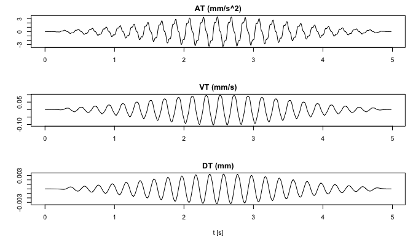

```r
op <- par(mfrow = c(3, 1), mar = c(4, 4, 2, 1))
plot(TSL[ID == "AT" & OCID == "H1", .(t, s)], type = "l",
     main = "AT (mm/s^2)", xlab = "", ylab = "")
plot(TSL[ID == "VT" & OCID == "H1", .(t, s)], type = "l",
     main = "VT (mm/s)",   xlab = "", ylab = "")
plot(TSL[ID == "DT" & OCID == "H1", .(t, s)], type = "l",
     main = "DT (mm)",     xlab = "t [s]", ylab = "")
```

```r
par(op)
```

## Intensity measures

`getIntensity()` consumes a long TSL with columns `RSN, OCID, ID, t, s`. It computes 20 + scalar measures per `(RSN, OCID, ID)` group: PGA / PGV / PGD, RMS, zero crossings, Arias intensity and its positive / negative variants, three significant-duration measures (D5–95, D5–75, D20–80), CAV and CAV5, mean period `Tm`, and the derived indices EPI and PDI.

```r
TSL[, RSN := "demo"]
IM <- getIntensity(TSL, units.source = "mm", units.target = "mm")

dcast(IM[IM %in% c("PGA", "PGV", "PGD", "AI", "D0595", "CAV")],
      OCID + IM ~ ., value.var = "value")
```

```
#> Key: <OCID, IM>
#>       OCID     IM            .
#>     <char> <char>        <num>
#>  1:     H1     AI 0.0014181966
#>  2:     H1    CAV 4.9524899520
#>  3:     H1  D0595 2.4750000000
#>  4:     H1    PGA 3.4213696194
#>  5:     H1    PGD 0.0032915973
#>  6:     H1    PGV 0.1035611225
#>  7:     H2     AI 0.0006313607
#>  8:     H2    CAV 3.3362355870
#>  9:     H2  D0595 2.4600000000
#> 10:     H2    PGA 2.3665485261
#> 11:     H2    PGD 0.0011334207
#> 12:     H2    PGV 0.0501314469
```

## Response spectrum

`TSL2PS()` integrates the SDOF equation of motion for a canonical `TSL` table and reports PSA / PSV / SD. It derives grouping keys from `TSL` metadata instead of requiring a public `BY` argument.

```r
Tn  <- 10 ^ seq(log10(0.05), log10(3), length.out = 60)

PS <- TSL2PS(TSL[OCID == "H1"], xi = 0.05, Tn = Tn, output = "PSL")

head(PS)
```

```
#>       RSN   OCID         Tn     ID        S
#>    <char> <char>      <num> <char>    <num>
#> 1:   demo     H1 0.00000000    PSA 3.421370
#> 2:   demo     H1 0.05000000    PSA 8.831002
#> 3:   demo     H1 0.05359301    PSA 6.370405
#> 4:   demo     H1 0.05744422    PSA 4.882943
#> 5:   demo     H1 0.06157217    PSA 4.297133
#> 6:   demo     H1 0.06599676    PSA 4.016459
```

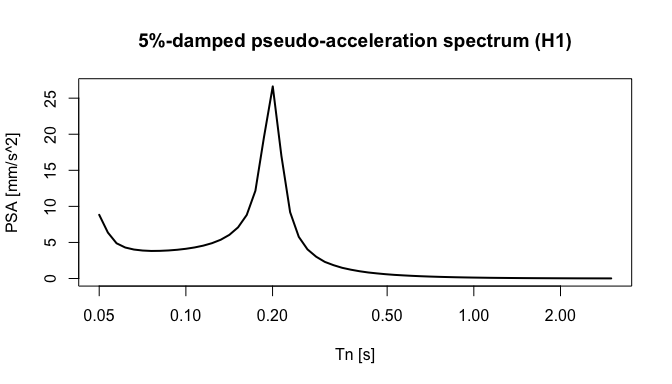

```r
plot(PS[ID == "PSA", .(Tn, S)], log = "x",
     type = "l", lwd = 2,
     xlab = "Tn [s]", ylab = "PSA [mm/s^2]",
     main = "5%-damped pseudo-acceleration spectrum (H1)")
```

## IMF decomposition

`TS2IMF()` decomposes one signal into intrinsic mode functions (EMD / EEMD / VMD) and a residue, optionally returning a reconstruction filtered by frequency content. Default engine is VMD.

```r
AT_H1 <- TSL[ID == "AT" & OCID == "H1", .(t, s)]
IMFs  <- TS2IMF(AT_H1, method = "vmd", K = 6, output = "TSW")

names(IMFs)
```

```
#> [1] "t"       "signal"  "IMF1"    "IMF2"    "IMF3"    "IMF4"    "IMF5"
#> [8] "IMF6"    "residue"
```

```r
head(IMFs[, 1:5])
```

[output not shown]

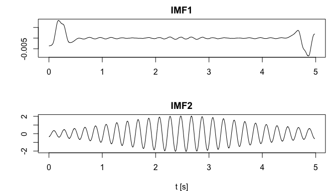

```r
op <- par(mfrow = c(2, 1), mar = c(4, 4, 2, 1))
plot(IMFs$t, IMFs$IMF1, type = "l",
     main = "IMF1", xlab = "", ylab = "")
plot(IMFs$t, IMFs$IMF2, type = "l",
     main = "IMF2", xlab = "t [s]", ylab = "")
```

```r
par(op)
```

## Where to go next

Additional vignettes ship with the package:

```r
vignette("signal-processing",  package = "gmsp")  # AT2TS / VT2TS / DT2TS math
vignette("imfs",               package = "gmsp")  # TS2IMF decomposition (EMD / EEMD / VMD)
vignette("spectra",            package = "gmsp")  # TSL2PS elastic SDOF spectra
vignette("intensity-measures", package = "gmsp")  # getIntensity output details
vignette("database",           package = "gmsp")  # optional file-based indexing layer
vignette("pipeline-runners",   package = "gmsp")  # optional JSON-driven batch runners
```

In-session help: `?AT2TS`, `?TS2IMF`, `?TSL2PS`, `?getIntensity`, or `help(package = "gmsp")`.

Rendered documentation: https://averriK.github.io/gmsp/.